# Wilcoxon Tests, Boxplots, and P-Values

Class Activity

Andrew Seaman

2025-5-21

## Questions

### Q1.

> *Let’s review some of the things we have learned so far this semester:*

#### Response

1. **Which function would you use to add a new column to your dataset?**
   - We would use `mutate()` or `summarize()`.

```r
KidsFeet2 <- KidsFeet %>%

  mutate(
    birthseason = case_when(
      birthmonth %in% c(12, 1, 2) ~ "Winter",
      birthmonth %in% c(3,4,5) ~ "Spring",
      birthmonth %in% c(6,7,8) ~ "Summer",
      birthmonth %in% c(9,10,11) ~ "Fall"
    )
  )

  datatable(head(KidsFeet2))
```

|  | name | birthmonth | birthyear | length | width | sex | biggerfoot | domhand | birthseason |
| --- | --- | --- | --- | --- | --- | --- | --- | --- | --- |
| 1 | David | 5 | 88 | 24.4 | 8.4 | B | L | R | Spring |
| 2 | Lars | 10 | 87 | 25.4 | 8.8 | B | L | L | Fall |
| 3 | Zach | 12 | 87 | 24.5 | 9.7 | B | R | R | Winter |
| 4 | Josh | 1 | 88 | 25.2 | 9.8 | B | L | R | Winter |
| 5 | Lang | 2 | 88 | 25.1 | 8.9 | B | L | R | Winter |
| 6 | Scotty | 3 | 88 | 25.7 | 9.7 | B | R | R | Spring |

2. **Which plots work best to display one quantitative variable that is separated into 2 or more groups?**
   - Box plots, violin plots, and dot/strip plots work well. They visualize distribution, central tendency, and spread.
   - From Brother Saunders:
     - If the sample size is fairly large, a boxplot could be used.
     - If the sample size is small, a dot plot is best.
     - If you want to get fancy with medium sample sizes, you could overlay a dotplot on top of a boxplot using either Base R:

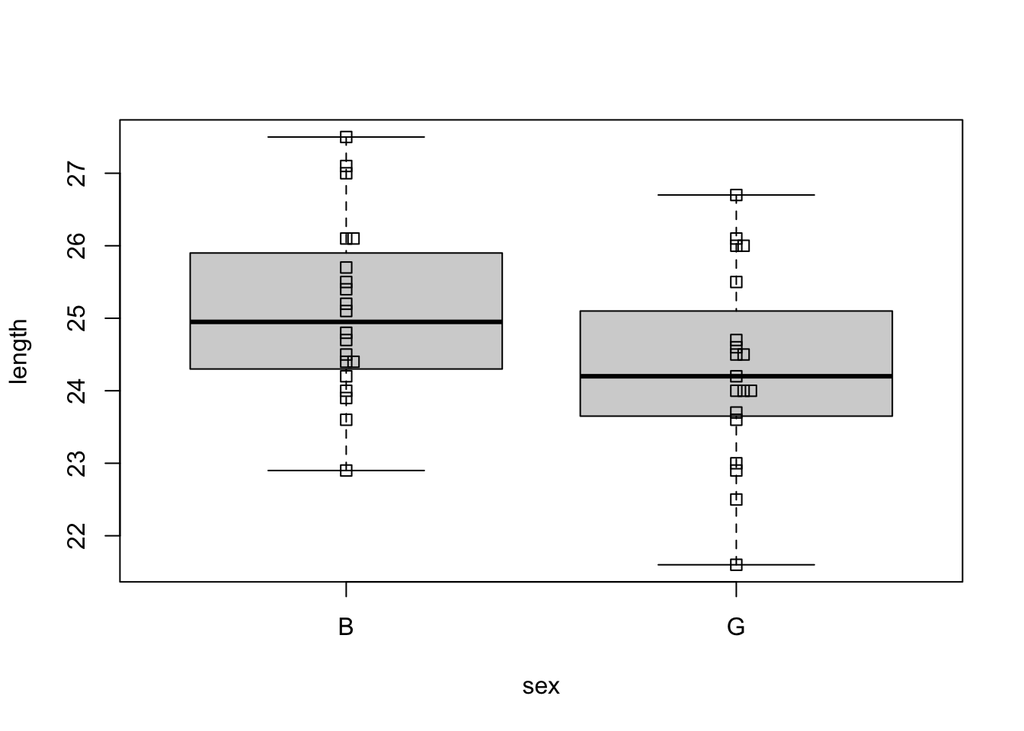

```r
boxplot(length ~ sex, data=KidsFeet)

stripchart(length ~ sex, data=KidsFeet, method="stack", vertical=TRUE, add=TRUE)
```

OR ggplot2:

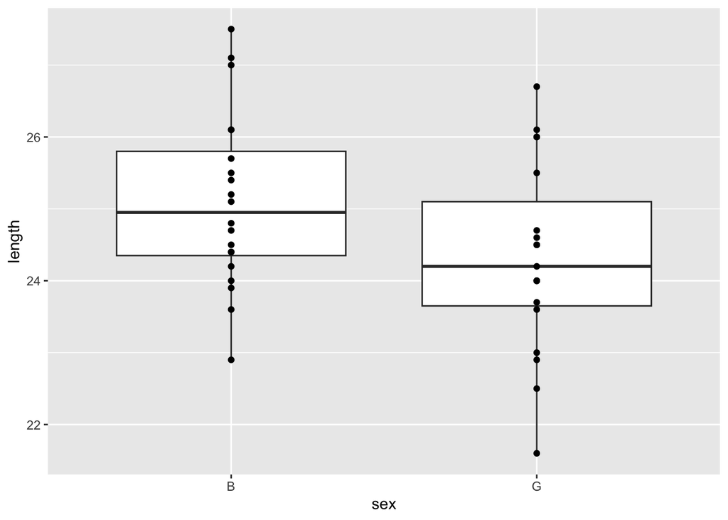

```r
ggplot(KidsFeet, aes(x=sex, y=length)) +

  geom_boxplot() +

  geom_point()
```

3. **What two things are needed to calculate a p-value?**
   - A test statistic (e.g., t-score)
   - The sampling distribution under the null hypothesis
4. **When would an independent samples t test be inappropriate to use but a Wilcoxon Rank Sum Test be appropriate?**
   - When the data are not normally distributed or when the sample sizes are small and unequal with strong outliers — Wilcoxon doesn’t assume normality.
   - (Brother Saunders): The independent samples t test is appropriate when the sample sizes are large or when the data in each group can be considered to be normal. It is inappropriate to use an independent samples t test when the sample sizes are small AND the data is clearly not normal in either group. This latter situation would still be appropriate for a Wilcoxon Rank Sum Test (as long as there weren’t too many “ties” in the data). The Wilcoxon Test can also be used on “ordinal” data, but the t test is not meaningful for such data.
5. **What is an appropriate set of hypotheses to use for an independent samples t test? For a Wilcoxon Rank Sum Test?**
   - **t Test**:
     - H₀: μ₁ = μ₂ (the means are equal)
     - H₁: μ₁ ≠ μ₂ (the means are different)
   - **Wilcoxon Rank Sum Test**:
     - H₀: The distributions of the two groups are equal
     - H₁: The distributions are not equal (often interpreted as a shift in median)

### Q2.

> *Your instructor will use the following applet for today’s class activity. You are welcome to follow along if you wish ([Mann-Whitney / Small Samples](https://shiny.byui.edu/StatClass/)).*

#### Response

1. **Explain what it means for the null hypothesis of a Wilcoxon Rank Sum Test to be true.**
   - It means the two groups come from the same distribution — there’s no systematic difference in ranks between them (i.e., no shift in medians).
2. **Explain what it means for the alternative hypothesis of a Wilcoxon Rank Sum Test to be true.**
   - It means the distributions differ — one group consistently has higher or lower ranks than the other, suggesting a shift in central tendency.
3. **Explain how boxplots for small sample sizes can be misleading.**
   - With small samples, boxplots can exaggerate or hide outliers, skewness, and spread. The quartiles might not represent the underlying distribution well, making patterns appear that aren’t statistically meaningful.
4. **Explain how the p-value helps us judge whether or not the null hypothesis or alternative hypothesis is the truth based on the evidence shown in a boxplot.**
   - The p-value quantifies how likely it is to see a difference as extreme as the one in the plot if the null hypothesis were true. A small p-value suggests the difference isn’t just a fluke and supports the alternative hypothesis.

### Q3.

> *This week’s analysis asks you to examine the results from a memory recall study. It is helpful to the success of this analysis if you experience some of the experiment yourself. To do this, open this [link](https://brainconnection.brainhq.com/brain-teasers/word-list-recall). Then, try the “Word List Recall” game and see how you do.*

#### Response

1. **How many words did you correctly recall?**
   - I recalled 4 words.

## Notes

### Additional Resources

1. Wilcoxon Tests

### `Mean()` vs. `Median()`

The **Wilcoxon tests** are more usefull than t-Tests when the data cannot be trusted to be normal, so the `mean()` is prone to following the tail of the data whereas the `median()` is far more stationary.

By using the `median()` we get a better sense for proportions of real or potential data points which belong in the various quantiles.